# Easy EDA in R, Using inspectdf and skimR

Barry DeCicco

For Ann Arbor R Users’ Group, June 11, 2020

## What this presentation covers

This will not be a detailed coverage of EDA, but it will introduce some methods to make it easier.  
This is important because hard EDA tends to be EDA not done.

#### Why Do Exploratory Data Analysis?

- **Make Sure that the import went well**
- **Find out what data you have - by column**
- **Find out what data you have - by row**

**The first point is not emphasized, but should be - when importing data sets, it’s really easy to have things not be understood correctly by R, resulting in numeric/date variables being read in as strings, or missing value codes not being undersood.**

## Load libraries:

- **janitor**,
- **kableExtra**
- **inspectdf**
- **skimr**
- **tidyverse**

## Data - Panguins This will use the ‘penguins’ data set, prepared by Allison Horst (https://github.com/allisonhorst):  
https://raw.githubusercontent.com/allisonhorst/palmerpenguins/master/data-raw/penguins_raw.csv

**Note that I have not worked with this data set before, so this is actual, gritty, real-life EDA!**

## Import the data set

**Import the data set from a .csv file on Allison Horts’ gitub site:**

```r
df_penguins <- read.csv("https://raw.githubusercontent.com/allisonhorst/palmerpenguins/master/data-raw/penguins_raw.csv", header=TRUE, stringsAsFactors=FALSE);
```

## Make Sure that the import went well.

- **Is the created object a data frame?**
- **What are the row/column counts? (what did you expect?)**
- **What are the column types? (Numeric/Character/Dates as expected)**

```r
options(width = 80)

print(class(df_penguins))
```

```
## [1] "data.frame"
```

```r
print(dim(df_penguins))
```

```
## [1] 344  17
```

## Find the type of each column - this produces a nicer table:

```r
options(width = 80)

# From:  https://stackoverflow.com/questions/40306280/how-to-transpose-a-dataframe-in-tidyverse

df_column_types <- lapply(df_penguins, class) %>%
  as.data.frame() %>%
  tibble::rownames_to_column() %>%
  pivot_longer(-rowname) %>%
  pivot_wider(names_from=rowname, values_from=value) %>%
  rename("Column_Name" = "name", "Column_Type" = "1")



library(gridExtra)
```

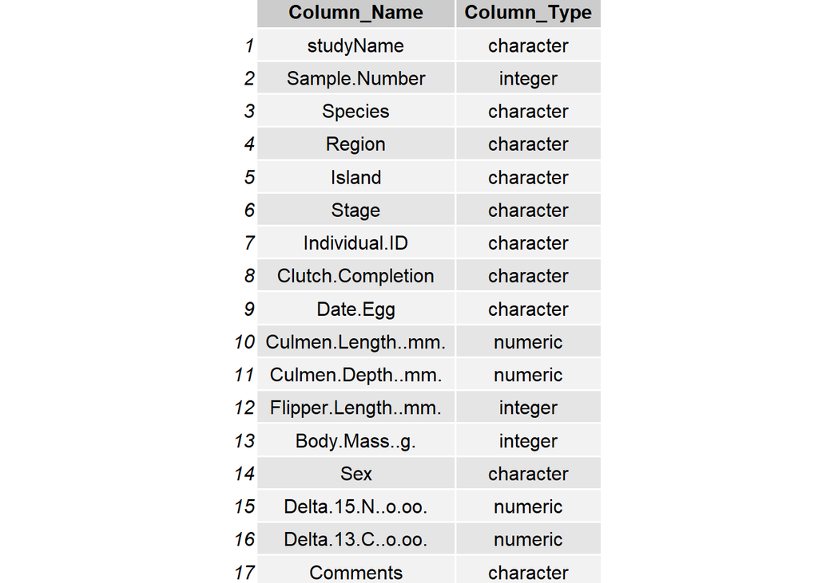

```r
grid.table(df_column_types)
```

## Find out what data you have - by column.

- **List unique values and counts for each column**
- **List missing value counts**

#### Skimr selects the appropriate summaries for character variables:

```r
 df_penguins %>%
  dplyr::select_if(is.character) %>%
  skim()
```

Data summary

| Name | Piped data |
| --- | --- |
| Number of rows | 344 |
| Number of columns | 10 |
| _______________________ |  |
| Column type frequency: |  |
| character | 10 |
| ________________________ |  |
| Group variables | None |

**Variable type: character**

| skim_variable | n_missing | complete_rate | min | max | empty | n_unique | whitespace |
| --- | --- | --- | --- | --- | --- | --- | --- |
| studyName | 0 | 1.00 | 7 | 7 | 0 | 3 | 0 |
| Species | 0 | 1.00 | 33 | 41 | 0 | 3 | 0 |
| Region | 0 | 1.00 | 6 | 6 | 0 | 1 | 0 |
| Island | 0 | 1.00 | 5 | 9 | 0 | 3 | 0 |
| Stage | 0 | 1.00 | 18 | 18 | 0 | 1 | 0 |
| Individual.ID | 0 | 1.00 | 4 | 6 | 0 | 190 | 0 |
| Clutch.Completion | 0 | 1.00 | 2 | 3 | 0 | 2 | 0 |
| Date.Egg | 0 | 1.00 | 10 | 10 | 0 | 50 | 0 |
| Sex | 10 | 0.97 | 1 | 6 | 0 | 3 | 0 |
| Comments | 290 | 0.16 | 18 | 68 | 0 | 10 | 0 |

## Skimr selects the appropriate summaries for numeric variables:

```r
df_penguins %>%
  dplyr::select_if(is.numeric) %>%
  skim()
```

Data summary

| Name | Piped data |
| --- | --- |
| Number of rows | 344 |
| Number of columns | 7 |
| _______________________ |  |
| Column type frequency: |  |
| numeric | 7 |
| ________________________ |  |
| Group variables | None |

**Variable type: numeric**

| skim_variable | n_missing | complete_rate | mean | sd | p0 | p25 | p50 | p75 | p100 | hist |
| --- | --- | --- | --- | --- | --- | --- | --- | --- | --- | --- |
| Sample.Number | 0 | 1.00 | 63.15 | 40.43 | 1.00 | 29.00 | 58.00 | 95.25 | 152.00 | ▇▇▆▅▃ |
| Culmen.Length..mm. | 2 | 0.99 | 43.92 | 5.46 | 32.10 | 39.23 | 44.45 | 48.50 | 59.60 | ▃▇▇▆▁ |
| Culmen.Depth..mm. | 2 | 0.99 | 17.15 | 1.97 | 13.10 | 15.60 | 17.30 | 18.70 | 21.50 | ▅▅▇▇▂ |
| Flipper.Length..mm. | 2 | 0.99 | 200.92 | 14.06 | 172.00 | 190.00 | 197.00 | 213.00 | 231.00 | ▂▇▃▅▂ |
| Body.Mass..g. | 2 | 0.99 | 4201.75 | 801.95 | 2700.00 | 3550.00 | 4050.00 | 4750.00 | 6300.00 | ▃▇▆▃▂ |
| Delta.15.N..o.oo. | 14 | 0.96 | 8.73 | 0.55 | 7.63 | 8.30 | 8.65 | 9.17 | 10.03 | ▃▇▆▅▂ |
| Delta.13.C..o.oo. | 13 | 0.96 | -25.69 | 0.79 | -27.02 | -26.32 | -25.83 | -25.06 | -23.79 | ▆▇▅▅▂ |